# STAT 360: Computational Statistics and Data Analysis

### Load Relevant R Libraries

```r
library(rmarkdown); library(knitr); library(moments);
library(scatterplot3d); library(corrplot); library(pso)
library(psych); library(GPArotation); library(lavaan); library(readxl); library(dplyr)
```

### Matrix Construction

```r
data_matrix_csv <- read.csv("C:/Users/User/OneDrive - University of St. Thomas/Classes/STAT360/STAT360 Project/data/Data Matrix.csv", row.names=1)
life_expectancy <- as.matrix(data_matrix_csv)

col_names_unedited <- c(
  "Life expectancy at birth, total (years)",
  "CO2 emissions (metric tons per capita)",
  "Access to electricity (% of population)",
  "Current health expenditure (% of GDP)",
  "Out-of-pocket expenditure (% of current health expenditure)",
  "Domestic private health expenditure per capita, PPP (current international $)",
  "Domestic general government health expenditure per capita, PPP (current international $)",
  "Renewable internal freshwater resources per capita (cubic meters)",
  "Prevalence of HIV, total (% of population ages 15-49)",
  "Unemployment, total (% of total labor force) (national estimate)",
  "Government Effectiveness: Estimate",
  "Income share held by highest 10%",
  "Prevalence of current tobacco use (% of adults)",
  "Total alcohol consumption per capita (liters of pure alcohol, projected estimates, 15+ years of age)",
  "Political Stability and Absence of Violence/Terrorism: Estimate",
  "Population density (people per sq. km of land area)"
)

# Better for displaying
col_names <- c(
  "Life_expectancy",
  "CO2_emissions",
  "Electricity",
  "Health_expenditure",
  "Out_of_pocket",
  "Private_health_expenditure",
  "Govt_health_expenditure",
  "Freshwater_resources",
  "HIV_prevalence",
  "Unemployment",
  "Govt_effectiveness",
  "Income_share",
  "Tobacco_use",
  "Alcohol_consumption",
  "Political_stability",
  "Population_density"
)

colnames(life_expectancy) <- col_names
```

### Central Tendency

The following are the means for all our countries across each dimension.

```r
mean_values <- apply(life_expectancy, 2, mean, na.rm = TRUE)
mean_values
```

```
##            Life_expectancy              CO2_emissions
##               7.293061e+01               4.073362e+00
##                Electricity         Health_expenditure
##               8.615784e+01               6.504190e+00
##              Out_of_pocket Private_health_expenditure
##               3.114537e+01               5.083869e+02
##    Govt_health_expenditure       Freshwater_resources
##               1.037831e+03               1.467286e+04
##             HIV_prevalence               Unemployment
##               1.696454e+00               7.304173e+00
##         Govt_effectiveness               Income_share
##              -3.457301e-02               2.737286e+01
##                Tobacco_use        Alcohol_consumption
##               2.070368e+01               5.411544e+00
##        Political_stability         Population_density
##              -3.458588e-02               4.421951e+02
```

### Dispersion

The following are our standard deviations for all our dimensions.

```r
sd_values <- apply(life_expectancy, 2, sd, na.rm = TRUE)
sd_values
```

```
##            Life_expectancy              CO2_emissions
##               7.524201e+00               4.685835e+00
##                Electricity         Health_expenditure
##               2.450012e+01               3.012619e+00
##              Out_of_pocket Private_health_expenditure
##               1.915046e+01               6.836306e+02
##    Govt_health_expenditure       Freshwater_resources
##               1.383151e+03               4.512422e+04
##             HIV_prevalence               Unemployment
##               4.173615e+00               5.179558e+00
##         Govt_effectiveness               Income_share
##               9.932636e-01               5.105692e+00
##                Tobacco_use        Alcohol_consumption
##               9.875615e+00               3.974219e+00
##        Political_stability         Population_density
##               1.000091e+00               1.984682e+03
```

### Shape

Kurtosis

```r
kurtosis_values <- apply(life_expectancy, 2, kurtosis, na.rm = TRUE)
kurtosis_values
```

```
##            Life_expectancy              CO2_emissions
##                   2.446652                  11.037460
##                Electricity         Health_expenditure
##                   4.796350                   5.686912
##              Out_of_pocket Private_health_expenditure
##                   2.678729                  28.528810
##    Govt_health_expenditure       Freshwater_resources
##                   5.216114                  67.935920
##             HIV_prevalence               Unemployment
##                  23.072125                   5.082456
##         Govt_effectiveness               Income_share
##                   2.462198                   3.500899
##                Tobacco_use        Alcohol_consumption
##                   2.413591                   2.072660
##        Political_stability         Population_density
##                   2.980892                  77.657754
```

Skewness

```r
skewness_values <- apply(life_expectancy, 2, skewness, na.rm = TRUE)
skewness_values
```

```
##            Life_expectancy              CO2_emissions
##                 -0.4937146                  2.4104904
##                Electricity         Health_expenditure
##                 -1.7349186                  1.2303785
##              Out_of_pocket Private_health_expenditure
##                  0.5991231                  4.1768408
##    Govt_health_expenditure       Freshwater_resources
##                  1.7346779                  7.4436728
##             HIV_prevalence               Unemployment
##                  4.3210884                  1.4514366
##         Govt_effectiveness               Income_share
##                  0.1128533                  0.9951699
##                Tobacco_use        Alcohol_consumption
##                  0.3718218                  0.3329518
##        Political_stability         Population_density
##                 -0.6245128                  8.4062661
```

Stripcharts

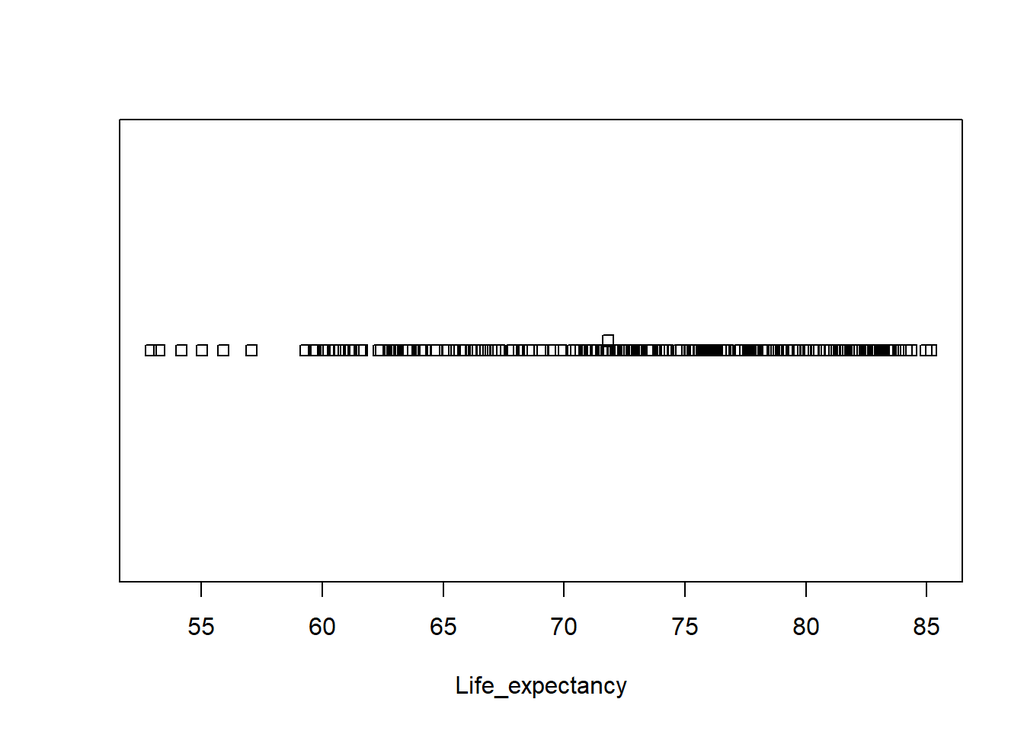

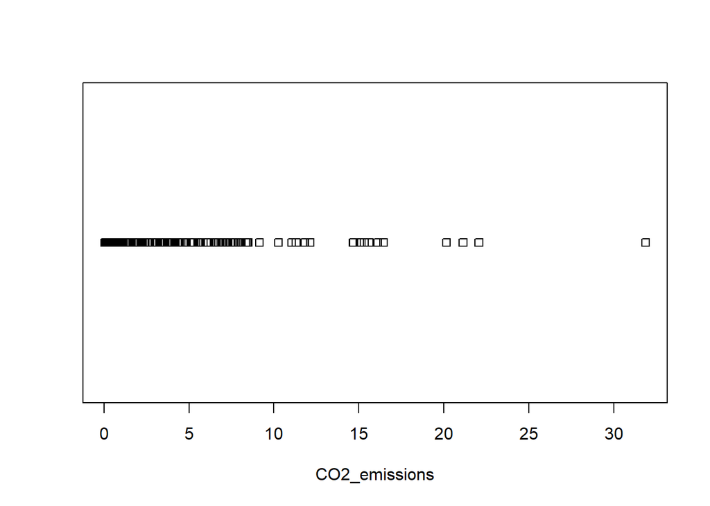

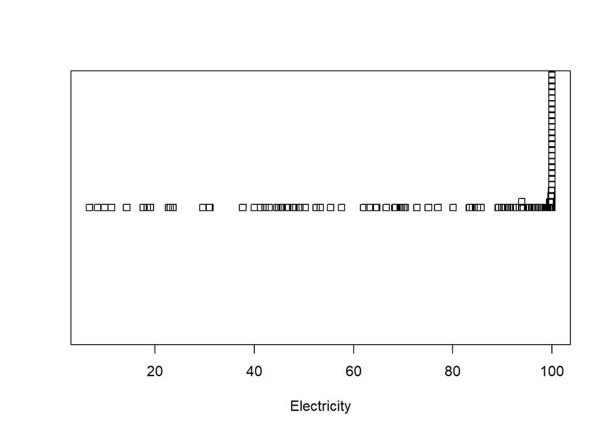

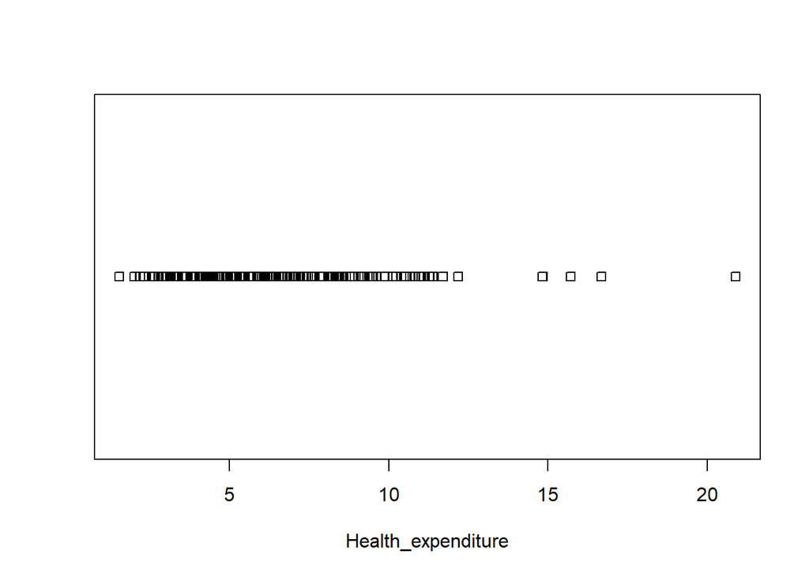

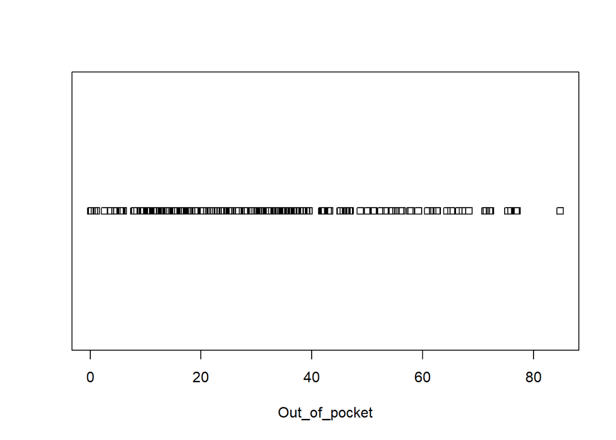

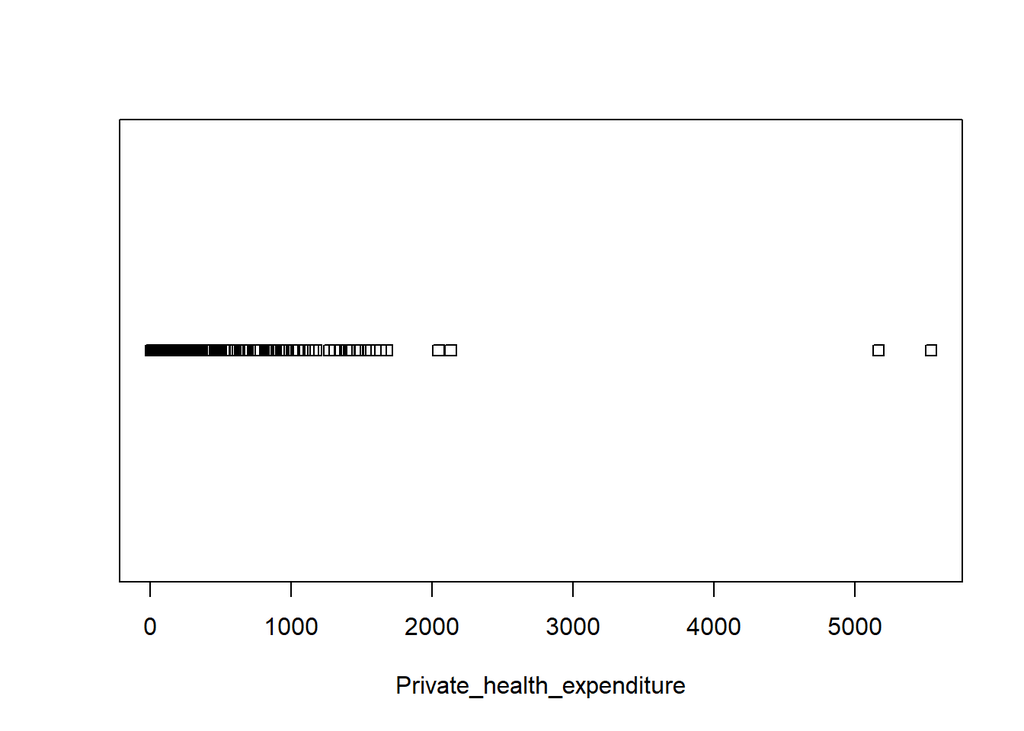

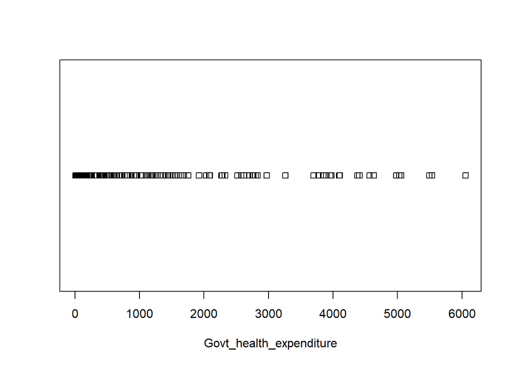

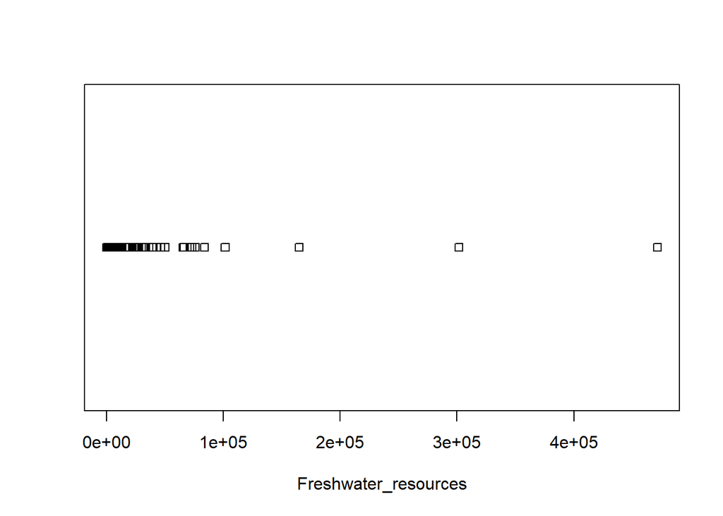

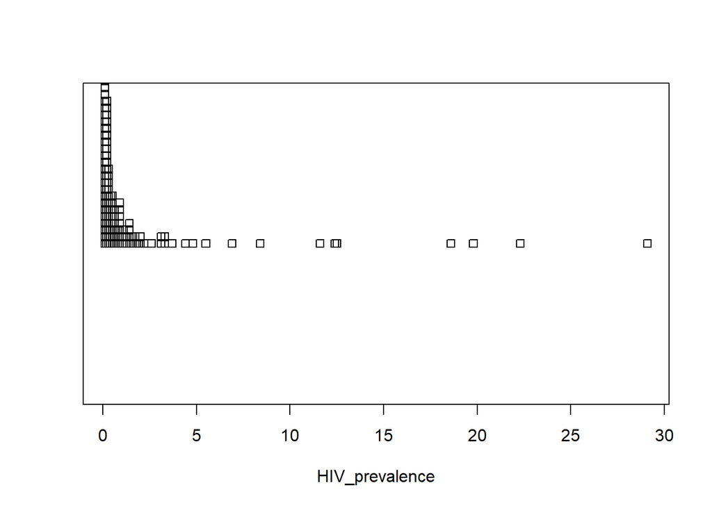

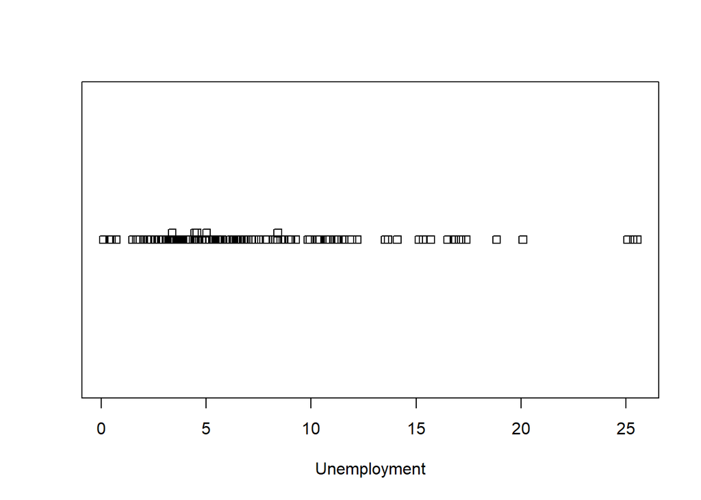

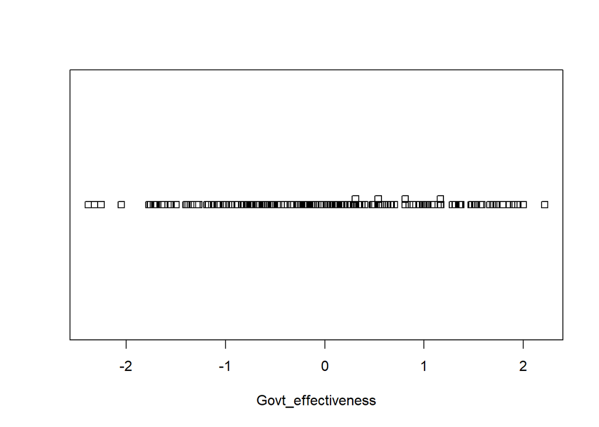

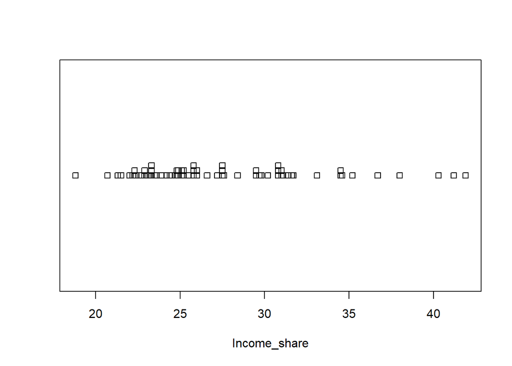

[4 more figures not shown]

```r
for (col in colnames(life_expectancy)) {
  stripchart(life_expectancy[, col], method = "stack", xlab = col)
}
```

### Variance-Covariance Matrix

```r
cov(life_expectancy, use = "pairwise.complete.obs")
```

```
##                            Life_expectancy CO2_emissions Electricity
## Life_expectancy                  56.613599     19.656000   143.90904
## CO2_emissions                    19.656000     21.957050    53.47077
## Electricity                     143.909039     53.470768   600.25600
## Health_expenditure                7.036888      1.901462    20.16410
## Out_of_pocket                   -45.276102    -27.520381   -83.98652
## Private_health_expenditure     2998.698602   1402.368831  6592.53067
## Govt_health_expenditure        7099.652598   3461.022535 14659.67137
## Freshwater_resources          27420.830532  -3207.162537 62163.79862
## HIV_prevalence                  -12.667762     -2.318291   -32.35660
## Unemployment                     -7.344768     -5.174830   -15.24628
## Govt_effectiveness                5.801790      2.442816    14.96731
## Income_share                    -10.354057     -6.177143   -25.58321
## Tobacco_use                      20.834585      2.787175    95.61148
## Alcohol_consumption              11.493254      3.239246    27.62556
## Political_stability               3.952635      1.505941    11.46460
## Population_density             2567.323142    329.437798  4734.90380
##                            Health_expenditure Out_of_pocket
## Life_expectancy                     7.0368878 -4.527610e+01
## CO2_emissions                       1.9014623 -2.752038e+01
## Electricity                        20.1640954 -8.398652e+01
## Health_expenditure                  9.0758757 -1.700235e+01
## Out_of_pocket                     -17.0023465  3.667401e+02
## Private_health_expenditure        937.5047198 -2.023200e+03
## Govt_health_expenditure          2040.0529666 -1.220182e+04
## Freshwater_resources             6400.0362573 -1.133978e+05
## HIV_prevalence                      0.4001537 -2.014671e+01
## Unemployment                        1.0674188 -4.466286e-01
## Govt_effectiveness                  0.9289957 -8.159019e+00
## Income_share                       -1.7383318  1.388092e+01
## Tobacco_use                         7.2202365 -2.657624e+01
## Alcohol_consumption                 2.9649858 -1.592692e+01
## Political_stability                 0.8223059 -9.718820e+00
## Population_density               -555.9827547 -2.308275e+03
##                            Private_health_expenditure Govt_health_expenditure
## Life_expectancy                             2998.6986               7099.6526
## CO2_emissions                               1402.3688               3461.0225
## Electricity                                 6592.5307              14659.6714
## Health_expenditure                           937.5047               2040.0530
## Out_of_pocket                              -2023.2004             -12201.8233
```

[output cut: 64 more lines]

```
## CO2_emissions                    3.294378e+02
## Electricity                      4.734904e+03
## Health_expenditure              -5.559828e+02
## Out_of_pocket                   -2.308275e+03
## Private_health_expenditure       8.181884e+04
## Govt_health_expenditure          2.520139e+05
## Freshwater_resources            -2.534178e+06
## HIV_prevalence                  -1.748864e+02
## Unemployment                    -1.438084e+03
## Govt_effectiveness               3.019097e+02
## Income_share                    -2.062068e+02
## Tobacco_use                      3.017917e+01
## Alcohol_consumption             -2.188422e+02
## Political_stability              3.456291e+02
## Population_density               3.938961e+06
```

### Correlation Matrix

```r
corr_life_expectancy <- cor(life_expectancy, use = "pairwise.complete.obs")
corr_life_expectancy
```

```
##                            Life_expectancy CO2_emissions Electricity
## Life_expectancy                 1.00000000    0.55999776  0.77132283
## CO2_emissions                   0.55999776    1.00000000  0.44798419
## Electricity                     0.77132283    0.44798419  1.00000000
## Health_expenditure              0.31923919    0.13514343  0.26203377
## Out_of_pocket                  -0.31590957   -0.30728110 -0.17169325
## Private_health_expenditure      0.58056287    0.43553278  0.37753174
## Govt_health_expenditure         0.69738997    0.54482614  0.41566298
## Freshwater_resources            0.08012279   -0.01489428  0.05322852
## HIV_prevalence                 -0.39485927   -0.12668544 -0.28164905
## Unemployment                   -0.21192883   -0.23554886 -0.20615394
## Govt_effectiveness              0.77980971    0.52486482  0.59899542
## Income_share                   -0.37869572   -0.35951654 -0.32397404
## Tobacco_use                     0.28087452    0.05925622  0.38439780
## Alcohol_consumption             0.39149428    0.17379124  0.27762335
## Political_stability             0.53205495    0.32815789  0.45844897
## Population_density              0.21361223    0.11350116  0.09715175
##                            Health_expenditure Out_of_pocket
## Life_expectancy                    0.31923919  -0.315909574
## CO2_emissions                      0.13514343  -0.307281100
## Electricity                        0.26203377  -0.171693247
## Health_expenditure                 1.00000000  -0.294703586
## Out_of_pocket                     -0.29470359   1.000000000
## Private_health_expenditure         0.45520572  -0.154539057
## Govt_health_expenditure            0.48854288  -0.459675206
## Freshwater_resources               0.05224326  -0.130707832
## HIV_prevalence                     0.03577408  -0.255857482
## Unemployment                       0.08557317  -0.005638088
## Govt_effectiveness                 0.32294387  -0.445579835
## Income_share                      -0.12632900   0.176219118
## Tobacco_use                        0.23675224  -0.141040002
## Alcohol_consumption                0.26096324  -0.211569324
## Political_stability                0.29600878  -0.550363714
## Population_density                -0.12557678  -0.082016388
##                            Private_health_expenditure Govt_health_expenditure
## Life_expectancy                            0.58056287               0.6973900
## CO2_emissions                              0.43553278               0.5448261
## Electricity                                0.37753174               0.4156630
## Health_expenditure                         0.45520572               0.4885429
## Out_of_pocket                             -0.15453906              -0.4596752
```

[output cut: 64 more lines]

```
## CO2_emissions                     0.113501161
## Electricity                       0.097151748
## Health_expenditure               -0.125576783
## Out_of_pocket                    -0.082016388
## Private_health_expenditure        0.081437450
## Govt_health_expenditure           0.124308889
## Freshwater_resources             -0.088584492
## HIV_prevalence                   -0.060200051
## Unemployment                     -0.144207934
## Govt_effectiveness                0.189027613
## Income_share                     -0.147034574
## Tobacco_use                       0.004574052
## Alcohol_consumption              -0.087996260
## Political_stability               0.169802564
## Population_density                1.000000000
```

### Scatterplot Matrix

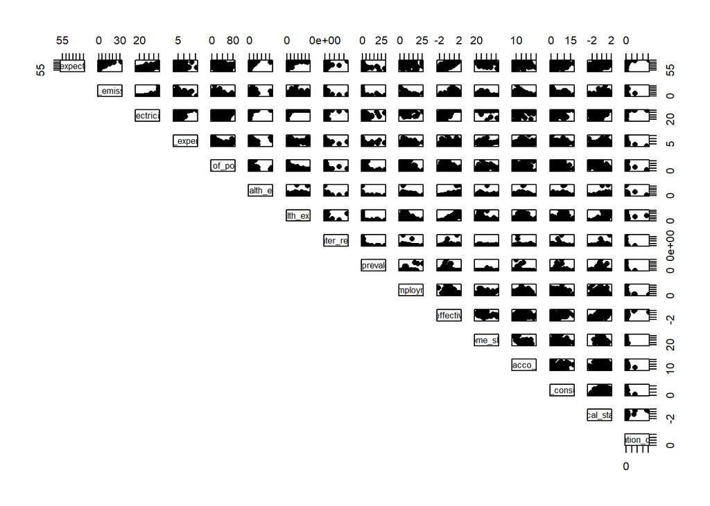

```r
pairs(life_expectancy, pch = 16, lower.panel = NULL)
```

### Correlation Plot

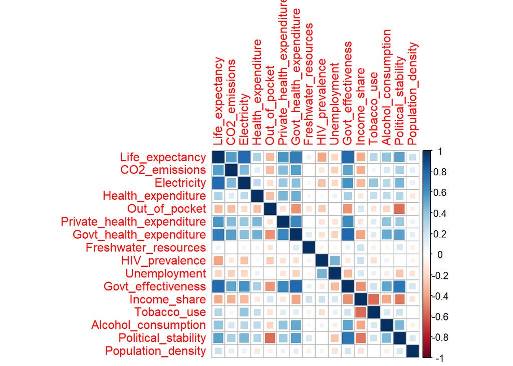

```r
corrplot(corr_life_expectancy, method = "square")
```

### Likely Outliers

The following is the concept we followed when identifying outliers.

1. Find a pair of dimensions that appear to have outliers on the **Scatterplot Matrix.**

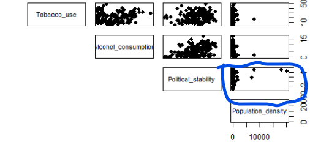

   ```r
   # dimension 1
   dim1 <- "Private_health_expenditure"  # CHANGE THIS
   # dimension 2
   dim2 <- "Income_share" # CHANGE THIS
   # pair of dimensions
   pair_dims <- c(dim1, dim2)

   # all rows between the pairs of dimensions
   rows_pair_dims <- life_expectancy[,pair_dims]
   # centroid
   centroid <- c(mean(life_expectancy[,dim1], na.rm = TRUE),
                 mean(life_expectancy[,dim2], na.rm = TRUE))
   # covariance matrix between dimensions
   cov_pair_dims <- cov(life_expectancy[,pair_dims], use = "pairwise.complete.obs")

   # mahalanobis distance for each row between these dimensions
   m_dims <- mahalanobis(x = rows_pair_dims,
                         center = centroid,
                         cov = cov_pair_dims)
   ```

3. Compare the Mahalanobis Distances for every row to the critical value to find the outliers.

   ```r
   # our constant critical value
   critical_value <- qchisq(p = 1 - 0.001, df = 2)

   # find which Mahalanobis distances for every row to the critical value
   outlierIndicies <- which(m_dims>critical_value)
   m_dims[outlierIndicies]
   ```

   ```
   ## United States
   ##      49.25951
   ```

4. Find the correlation matrices for our pair of dimensions with and without each outlier to see if it is significant.

   ```r
   for (outlier in outlierIndicies) {
      cor_with <- cor(life_expectancy[,pair_dims],
                      use = "pairwise.complete.obs")
      cor_without <- cor(life_expectancy[-outlier, pair_dims],
                         use = "pairwise.complete.obs")
      print(rownames(life_expectancy)[outlier])
      print(cor_with)
      print(cor_without)
      cat('\n')
      cat('\n')
   }
   ```

   ```
   ## [1] "United States"
   ##                            Private_health_expenditure Income_share
   ## Private_health_expenditure                  1.0000000   -0.1370584
   ## Income_share                               -0.1370584    1.0000000
   ##                            Private_health_expenditure Income_share
   ## Private_health_expenditure                  1.0000000   -0.2949124
   ## Income_share                               -0.2949124    1.0000000
   ```

### Find All Outliers

The following takes the idea above and does it for all pairs of dimension (however a bit redundantly).

```r
outlier_matrix <- matrix(nrow = 0, ncol = 4)
colnames(outlier_matrix) <- c("Country", "dim1", "dim2", "MD")
```

```r
for (i in col_names) {
  other_col_names <- col_names[col_names != i]
  for (j in other_col_names) {
    # dimension 1
    dim1 <- i
    # dimension 2
    dim2 <- j
    # pair of dimensions
    pair_dims <- c(dim1, dim2)

    # all rows between the pairs of dimensions
    rows_pair_dims <- life_expectancy[,pair_dims]
    # centroid
    centroid <- c(mean(life_expectancy[,dim1], na.rm = TRUE),
                  mean(life_expectancy[,dim2], na.rm = TRUE))
    # covariance matrix between dimensions
    cov_pair_dims <- cov(life_expectancy[,pair_dims], use = "pairwise.complete.obs")

    # mahalanobis distance for each row between these dimensions
    m_dims <- mahalanobis(x = rows_pair_dims,
                          center = centroid,
                          cov = cov_pair_dims)
    # our constant critical value
    critical_value <- qchisq(p = 1 - 0.001, df = 2)

    # find which Mahalanobis distances for every row to the critical value
    outlierIndicies <- which(m_dims>critical_value)
    m_dims[outlierIndicies]

    for (outlier in outlierIndicies) {
      country <- rownames(life_expectancy)[outlier]
      m_dist <- m_dims[outlier]
      outlier_matrix <- rbind(outlier_matrix, c(country, dim1, dim2, m_dist))
      cor_with <- cor(life_expectancy[,pair_dims],
                   use = "pairwise.complete.obs")
      cor_without <- cor(life_expectancy[-outlier, pair_dims],
                          use = "pairwise.complete.obs")
      change <- abs(cor_with[2,1]-cor_without[2,1])
      if (change > 0.3) {
        cat(sprintf("%s is an influetial outlier for the dimensions %s and %s as the correlation changes by %.3f", country, dim1, dim2, change))
        cat('\n')
        cat('\n')
      }
    }
  }
}
```

We have many outliers in the following matrix, but several that are redundant. We attempted to avoid this but are unsure how to achieve this. However it is of note that none of these outliers were actually found to be influential based on the code we wrote.

```r
outlier_matrix
```

```
##        Country                dim1
##   [1,] "Bahrain"              "Life_expectancy"
##   [2,] "Kuwait"               "Life_expectancy"
##   [3,] "Qatar"                "Life_expectancy"
##   [4,] "Tuvalu"               "Life_expectancy"
##   [5,] "Switzerland"          "Life_expectancy"
##   [6,] "United States"        "Life_expectancy"
##   [7,] "Norway"               "Life_expectancy"
##   [8,] "United States"        "Life_expectancy"
##   [9,] "Guyana"               "Life_expectancy"
##  [10,] "Iceland"              "Life_expectancy"
##  [11,] "Botswana"             "Life_expectancy"
##  [12,] "Eswatini"             "Life_expectancy"
##  [13,] "Lesotho"              "Life_expectancy"
##  [14,] "South Africa"         "Life_expectancy"
```

[output cut: 819 more lines]